# Coursework Report

*N* removed NAs: 2

*N* removed typo: 1

*N* removed <18: 12

*N* total clean: 135

| Group | *N* | *M*<sub>age</sub> | *M*<sub>rating</sub> |
| --- | --- | --- | --- |
| Control | 70 | 20.6 | 6.72 |
| Experim | 65 | 20.5 | 5.71 |

**Main analysis results**

*t*(133) = 7.53, *p* < .001

[interactive chart not shown]

[figure not shown]

[interactive chart not shown]

# Coursework Report

Analysing Data, Spring 2020

This student has a record of specific learning difficulty (dyslexia/dyspraxia). Please mark this report in accordance with the [marking guidelines for SLD](https://www.sussex.ac.uk/studentsupport/staff/spld?fbclid=IwAR2lYKD6xvuv9egQDvG8d_oed9GUD3KXQn3gAdlHZ1gQB8gDddBdeOEmKdE).

# Methods

## Participants

The study was conducted using a sample of 135 participants (*M*<sub>age</sub> = 20.56, *SD*<sub>age</sub> = 1.84, range = 18 - 27). Data from 12 participants were excluded to follow ethical considerations (anyone under the age of 18). 3 more participants were excluded due to age being unprovided or unclear. Therefore, the sample decreased from 150 to 135. Table 1 shows the descriptive statistics by age.

Table 1 *Descriptive Statistics by Age*

| Mean | Standard Deviation | Minimum | Maximum |
| --- | --- | --- | --- |
| 20.6 | 1.84 | 18 | 27 |

## Design

The study aimed to investigate whether the colour red would make women perceive men as more attractive. The colour red was selected as the experimental condition and the control was white. Participants were shown a photo of man with either a red background or white depending on the condition. Therefore, the predictor is the condition participants are assigned to, which is two levels so either seeing a photo with a red or white background. The outcome is the rating of attractiveness women give to each question (continuous variable).

They were then asked 3 questions to determine attractiveness: “How attractive do you think this person is?”, “How pleasant is this person to look at?” and “If I were to meet this person in this picture face to face, I would think he is attractive”. Participants were asked to rate the person using a scale where 1 is extremely unattractive and 9 is extremely attractive. It was hypothesised that women would find the photo of the man with the red background more attractive than with the white background. To analyse the comparison of the two means I will perform a t-test.

# Results

The graph below shows the difference in mean rating of attractiveness in the condition group and experimental group.

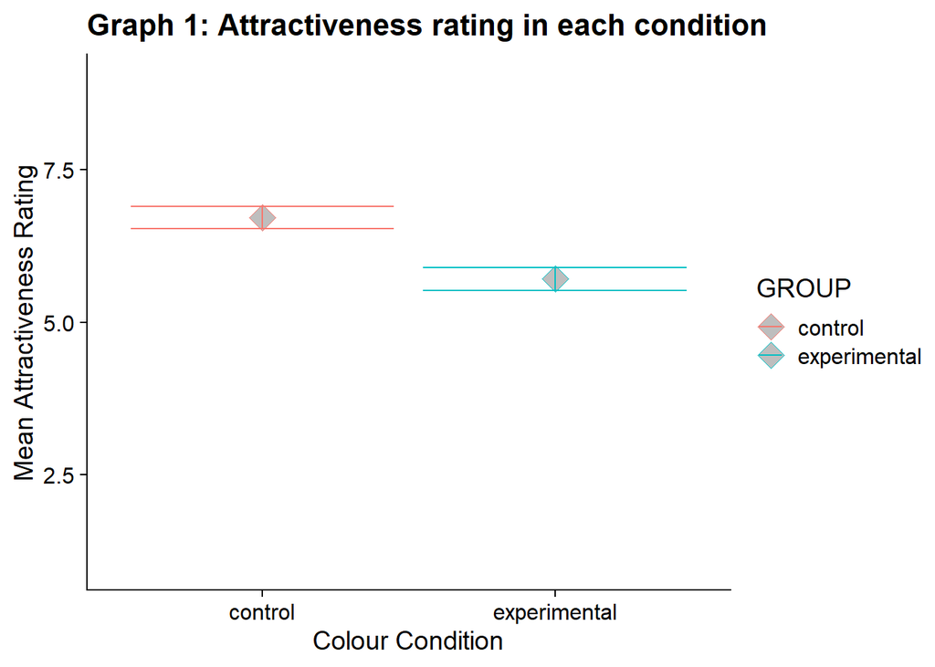

From the graph, it is clear that the control condition (white background) had a higher mean attractiveness rating than the experimental condition (red background). A t-test was performed to analyse the difference in the means between the condition and experimental group. The control group had a mean of 6.72, and the experimental group had a mean of 5.71. This difference was significant (*M*<sub>diff</sub> = 1.01, 95% CI [0.75, 1.28], *t*(133)= 7.53, *p* < 0.001).The null hypothesis of the t-test is that the two means come from the same population, which group they are in (this case, whether they saw a red or white background) makes no difference to attractiveness rating. If so, and the null hypothesis is true the difference in sample means should be 0. As we can see in the study, the difference in the sample means is not 0, it is 1.01, on the scale of 1-9. This suggests it is a big enough difference to believe our two samples came from different populations.

In short, the result of our analysis suggests that whether a participant saw a red or white background does influence their rating of attractiveness because p was less than 0.001. However, the direction of this influence is the opposite of the hypothesis. Therefore, the colour white influenced the female participants to rate the male in the photo as more attractive.

# Discussion

The results showed that the colour white influenced the participants rating of attractiveness to increase compared to the colour red. Contrast, to the original study which found that the colour red increased rating of attractiveness (Elliot, 2010). Therefore, my results are not congruent with Elliot’s famous study. This may suggest that there are individual differences in perceived attractiveness. It is possible that participants in Elliot’s study found the colour red more attractive, however, participants in this study found the colour white more attractive. Other studies that have investigated the same topic have found different findings. Multiple studies have questioned and contradicted Elliot’s study, and found that the colour red has no effect on human mate preferences (Peperkoorn et al., 2016; Hesslinger et al., 2015). It is clear that the topic is complex from all the different findings. This reinforces the idea that individual differences may play a role as well as other factors. Ideally, the participants need to be more representative than my participants used. They need to have more varied ages, and it would be interesting to monitor race, to investigate cultural differences.

# References

Dubuc, C., Allen, W. L., Maestripieri, D., & higham, J. P. (2014). Is male rhesus macaque red colour ornamentation attractive to females?. *Behavioural ecology and socio-biology, 68*(7), 1215-1224.

Elliot, A. J., Niesta Kayser, D., Greitemeyer, T., Lichtenfeld, S., Gramzow, R. H., Maier, M. A., & Liu, H. (2010). Red, rank and romance in women viewing men. *Journal of Experimental Psychology: General, 139*(3), 399-417.

Hesslinger, V. M., Goldbach, L., & Carbon, C. C. (2015). Men in red: A reexamination of the red-attractiveness effect. *Psychonomic bulletin & review, 22*(4), 1142-1148.

Peperkoorn, L. S., Roberts, S. C., & Pollet, T. V. (2016). Revisiting the red effect on attractiveness and secual receptivity: No effect of the colour red on human mate preferences. *Evolutionary Psychology, 14*(4), 1474704916673841.